## # Project1

title: “Scooby-Doo” author: “Sara Knight” date: “2/23/2022” output: github_document —

```r
library(tidyverse)
```

```r
library(ggplot2)
library(infer)
```

This is one of my examples of loading data.

```r
scoobydoo <- readr::read_csv('https://raw.githubusercontent.com/rfordatascience/tidytuesday/master/data/2021/2021-07-13/scoobydoo.csv')
```

| Header | Description |
| --- | --- |
| `index` | Index ordering based on Scoobypedia (dbl) |
| `series_name` | Name of Series (char) |
| `network` | TV Network TV series takes place in (char) |
| `season` | Season of TV Series (char) |
| `title` | Title of Show/Movie (char) |
| `imbd` | Score on IMBD (char) |
| `engagment` | Number of Reviews on IMBD (char) |
| `date_aired` | Date aired in US (dbl) |
| `run_time` | Run time in min (dbl) |
| `format` | Type of media (char) |
| `monster_name` | Name of monster (char) |
| `monster_gender` | Binary monster gender (char) |
| `monster_type` | Monster type (char) |
| `monster_subtype` | Monster subtype (char) |
| `monster_species` | Monster species (char) |
| `monster_real` | Was monster real (char) |
| `monster_amount` | Monster amount (dbl) |
| `caught_fred` | Caught by Fred (char) |
| `caught_daphnie` | Caught by Daphnie (char) |
| `caught_velma` | Caught by Velma (char) |
| `caught_shaggy` | Caught by Shaggy (char) |
| `caught_scooby` | Caught by Scooby (char) |
| `captured_fred` | Captured Fred (char) |
| `captured_daphnie` | Captured Daphnie (char) |
| `captured_velma` | Captured Velma (char) |
| `captured_shaggy` | Captured Shaggy (char) |
| `captured_scooby` | Captured Scooby (char) |
| `unmask_fred` | Unmasked by Fred (char) |
| `unmask_daphnie` | Unmasked by Daphnie (char) |
| `unmask_velma` | Unmasked by Velma (char) |
| `unmask_shaggy` | Unmasked by Shaggy (char) |
| `unmask_scooby` | Unmasked by Scooby (char) |
| `snack_fred` | Snack eaten by Fred (char) |
| `snack_daphnie` | Snack eaten by Daphnie (char) |
| `snack_velma` | Snack eaten by Velma (char) |
| `snack_shaggy` | Snack eaten by Shaggy (char) |
| `snack_scooby` | Snack eaten by Scooby (char) |
| `unmask_other` | Unmasked by other (chat) |
| `caught_other` | Caught by other (char) |
| `caught_not` | Not caught (logical) |
| `trap_work_first` | Trap worked first time (char) |
| `caught_shaggy` | Caught by Shaggy (char) |
| `setting_terrain` | Setting type of terrain (char) |
| `setting_country_state` | Setting Country State (char) |
| `suspect_amount` | Suspect amount (dbl) |
| `non_suspect` | Non suspect (char) |
| `arrested` | Arrested (char) |
| `culprit_name` | Culprit name (char) |
| `culprit_gender` | Culprit binary gender(char) |
| `culprit_amount` | Culprit amount (dbl) |
| `motive` | Motive (char) |
| `if_it_wasn't_for` | Phrase at end the of the show (char) |
| `door_gag` | Door gag happened (logical) |
| `number_of_snacks` | Number of snacks (char) |
| `split_up` | Did they split up (char) |
| `another_mystery` | Another mystery (char) |
| `set_a_trap` | Did they set a trap (char) |
| `jeepers` | Times “Jeepers” said (char) |
| `jinkies` | Times “Jinkies” said (char) |
| `my_glasses` | Times “My glasses” said (char) |
| `just_about_wrapped_up` | Times “Just about wrapped up” said (char) |
| `zoinks` | Times “Zoinks” said (char) |
| `groovy` | Times “Groovy” said (char) |
| `scooby_doo_where_are_you` | Times “Scooby doo where are you” said (char) |
| `rooby_rooby_roo` | Times “Rooby rooby roo” said (char) |
| `batman` | Batman in episode (logical) |
| `scooby_dum` | Scooby Dum in episode (logical) |
| `scrappy_do` | Scrappy Doo in episode (logical) |
| `hex_girls` | Hex Girls in episode (logical) |
| `blue_falcon` | Blue Falcon in episode (logical) |
| `fred_va` | Fred voice actor (char) |
| `daphnie_va` | Daphnie voice actor (char) |
| `velma_va` | Velma voice actor (char) |
| `shaggy_va` | Shaggy voice actor (char) |
| `scooby_va` | Scooby voice actor (char) |

**Ideas** 1. color-coordinated 2. pull fonts from the internet 5. Keep the movies/ Get rid of the movies? 6. What do they mean by crossover? 7. I want to look at making a map graphic of the locations of the episodes.

**Trying to create a color palette for our project**

```r
 scooby_gang_colors <- function(...) {
   palette <- c(`Shaggy Green` = "#B8B#19",
                   `Shaggy Red Brown` ="#A44138",
                   `Velma Orange` = "#F8991D",
                   `Velma Red` = "#C70C47",
                   `Daphne Green` = "#D0D61B",
                   `Daphne Dark Purple` = "#6352A3",
                   `Scooby Brown` = "#6A3400",
                   `Scooby Blue` = "#7BDB9",
                   `Fred Blue` ="#009DDC",
                   `Fred Orange`= "#F47920",
                   `Mystery Machine Green` = "#00CFD4",
                   `Mystery Machine Blue` ="#00E304")


  cols <-c(...)

  if (is.null(cols))
    return(palette)

  palette[cols]
}

#scooby_gang_colors("Shaggy Green") This was to check if it worked
```

https://drsimonj.svbtle.com/creating-corporate-colour-palettes-for-ggplot2

**This is me creating data sets for crossovers, tv shows, tv show segmented(I don’t know what this means), and movies**

```r
scoobydoo_tv <- scoobydoo %>%
  filter(format == "TV Series")

scoobydoo_tv_segmented <- scoobydoo %>%
  filter(format == "TV Series (segmented)")

scoobydoo_crossover <- scoobydoo %>%
  filter(format == "Crossover")

scoobydoo_movie <- scoobydoo %>%
  filter(format == "Movie")
```

This is my attempt a looking at all the places Mystery Inc has been.

Here I filter the data in order to make a smaller data frame. Then I changed data points points so I could join this data fram with another. Finally I filtered out the data points that weren’t useful to making my map.

This is also an example of creating a graphical display of the world with a gradient of how many episodes were in the country.

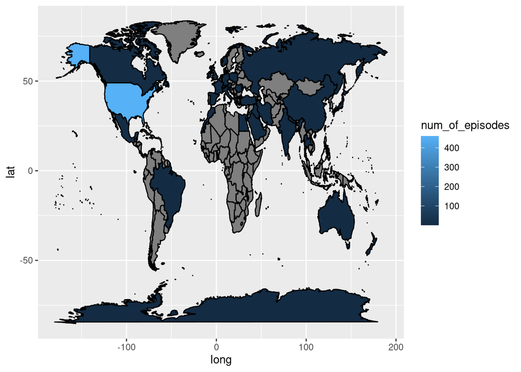

```r
scoobydoo_earth <- scoobydoo %>%
  select(setting_country_state)

scoobydoo_earth[scoobydoo_earth == "United States"] <- "USA"

scoobydoo_earth[scoobydoo_earth == "Alaska"] <- "USA"

scoobydoo_earth[scoobydoo_earth == "Arizona"] <- "USA"

scoobydoo_earth[scoobydoo_earth == "California"] <- "USA"

scoobydoo_earth[scoobydoo_earth == "Colorado"] <- "USA"

scoobydoo_earth[scoobydoo_earth == "Alaska"] <- "USA"

scoobydoo_earth[scoobydoo_earth == "Florida"] <- "USA"

scoobydoo_earth[scoobydoo_earth == "Georgia"] <- "USA"

scoobydoo_earth[scoobydoo_earth == "Hawaii"] <- "USA"

scoobydoo_earth[scoobydoo_earth == "Illinois"] <- "USA"

scoobydoo_earth[scoobydoo_earth == "Kentucky"] <- "USA"

scoobydoo_earth[scoobydoo_earth == "Kentukey"] <- "USA"

scoobydoo_earth[scoobydoo_earth == "Alaska"] <- "USA"

scoobydoo_earth[scoobydoo_earth == "Louisiana"] <- "USA"

scoobydoo_earth[scoobydoo_earth == "Massachusetts"] <- "USA"

scoobydoo_earth[scoobydoo_earth == "Mississippi"] <- "USA"

scoobydoo_earth[scoobydoo_earth == "Missouri"] <- "USA"

scoobydoo_earth[scoobydoo_earth == "Nevada"] <- "USA"

scoobydoo_earth[scoobydoo_earth == "New Jersey"] <- "USA"

scoobydoo_earth[scoobydoo_earth == "New Mexico"] <- "USA"

scoobydoo_earth[scoobydoo_earth == "New York"] <- "USA"

scoobydoo_earth[scoobydoo_earth == "North Carolina"] <- "USA"

scoobydoo_earth[scoobydoo_earth == "Pennsylvania"] <- "USA"

scoobydoo_earth[scoobydoo_earth == "Ohio"] <- "USA"

scoobydoo_earth[scoobydoo_earth == "Rhode Island"] <- "USA"

scoobydoo_earth[scoobydoo_earth == "Tennessee"] <- "USA"

scoobydoo_earth[scoobydoo_earth == "Texas"] <- "USA"

scoobydoo_earth[scoobydoo_earth == "Vermont"] <- "USA"

scoobydoo_earth[scoobydoo_earth == "Washington"] <- "USA"

scoobydoo_earth[scoobydoo_earth == "Washington D.C."] <- "USA"

scoobydoo_earth[scoobydoo_earth == "Wisconsin"] <- "USA"

scoobydoo_earth[scoobydoo_earth == "England"] <- "UK"

scoobydoo_earth[scoobydoo_earth == "Scotland"] <- "UK"

scoobydoo_earth[scoobydoo_earth == "Hong Kong"] <- "China"

scoobydoo_earth[scoobydoo_earth == "Siam"] <- "Thailand"

scoobydoo_earth <- scoobydoo_earth %>%
  group_by(setting_country_state) %>%
  summarise(num_of_episodes = n()) %>%
  select(setting_country_state, num_of_episodes) %>%
  filter(setting_country_state != "Atlantis") %>%
  filter(setting_country_state != "Bermuda Triangle") %>%
  filter(setting_country_state != "Indian Reserve") %>%  # Too vague
  filter(setting_country_state != "Mars") %>%
  filter(setting_country_state != "Moon") %>%
  filter(setting_country_state != "Pre-Historic") %>%
  filter(setting_country_state != "Space") %>%
  filter(setting_country_state != "Africa") %>% # Africa is a continent
  filter(setting_country_state != "Caribean") %>% # Caribean is part of many countries
  filter(setting_country_state != "South America") %>% #South America is a continent
  filter(setting_country_state != "Tibet") #I don't know enough about the history of Tibet

names(scoobydoo_earth)[names(scoobydoo_earth) == "setting_country_state"] <- "region"

mapdata <- map_data("world")

mapdata <-left_join(mapdata, scoobydoo_earth, by = "region")

#mapdata1 <- mapdata %>% filter(!is.na(mapdata$num_of_episodes)) This was making it so I couldn't see all the countries and commenting it out fixed it.

map1 <- ggplot(mapdata, aes(x = long, y = lat, group = group))+
  geom_polygon(aes(fill = num_of_episodes), color = "black")
map1
```

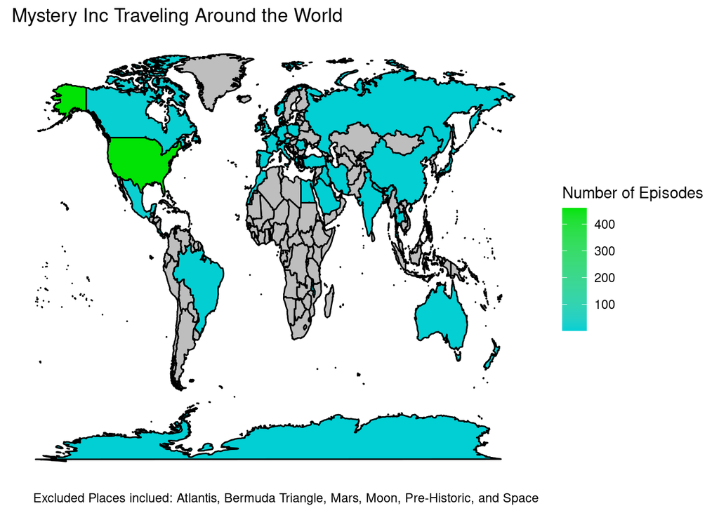

```r
scoobydoo_world_map <- map1 + scale_fill_gradient(name = "Number of Episodes", low = scooby_gang_colors("Mystery Machine Green"), high = scooby_gang_colors("Mystery Machine Blue"), na.value = "gray")+
  labs(title = "Mystery Inc Traveling Around the World",
       caption = "Excluded Places inclued: Atlantis, Bermuda Triangle, Mars, Moon, Pre-Historic, and Space")+
  theme(axis.text.x = element_blank(),
      axis.text.y = element_blank(),
      axis.ticks = element_blank(),
      axis.title.x = element_blank(),
      axis.title.y = element_blank(),
      rect = element_blank())
scoobydoo_world_map
```

I used this (youtube video)[https://www.youtube.com/watch?v=AgWgPSZ7Gp0] to find out how to make the world map

[figure not shown]

```r
scoobydoo_cp <- scoobydoo %>%
  select("another_mystery", "jeepers", "jinkies", "my_glasses", "zoinks","groovy","rooby_rooby_roo")

scoobydoo_cp[scoobydoo_cp == "NULL"] <- "0"

scoobydoo_cp[] <- lapply(scoobydoo_cp, as.numeric)

fred <- sum(scoobydoo_cp$another_mystery)
daphne <- sum(scoobydoo_cp$jeepers)
velma1 <- sum(scoobydoo_cp$jinkies)
velma2 <- sum(scoobydoo_cp$my_glasses)
shaggy1 <- sum(scoobydoo_cp$zoinks)
shaggy2 <- sum(scoobydoo_cp$groovy)
scooby <- sum(scoobydoo_cp$rooby_rooby_roo)

velma <- sum(velma1,velma2)
shaggy <- sum(shaggy1,shaggy2)

character <- c("Fred", "Daphne", "Velma", "Shaggy", "Scooby")
catch_phrase <- c(fred, daphne, velma, shaggy, scooby)

gang_cp <- data.frame(character, catch_phrase)

ggplot(data = gang_cp)+
  geom_bar(mapping = aes(x = character, y = catch_phrase), stat = "identity")+
  scale_fill_manual(values =c("Fred" = scooby_gang_colors("Fred Blue"),
                              "Daphne" = scooby_gang_colors("Daphne Purple"),
                              "Velma" = scooby_gang_colors("Velma Orange"),
                              "Shaggy" =scooby_gang_colors("Shaggy Green"),
                              "Scooby" = scooby_gang_colors("Scooby Brown")))
```

```r
hex_girls_guest_star <- scoobydoo %>%
  filter(hex_girls != "FALSE")

batman_guest_star <- scoobydoo %>%
  filter(batman != "FALSE")

blue_falcon_guest_star <- scoobydoo %>%
  filter(blue_falcon != "FALSE")

scooby_dum_guest_star <- scoobydoo %>%
  filter(scooby_dum != "FALSE")

scrappy_doo_guest_star <- scoobydoo %>%
  filter(scrappy_doo != "FALSE")

#Left Join These
#Also you want to do something with catch phrases
```